# Mtcars Mean Calculator App Pitch

July 18, 2017

## What the App does

This simple Shiny app will determine the mean of a car parameter across three different cylinder classes.  
This data, sourced from the 1974 "mtcars" dataset in Rstudio, is then plotted via an interactive barchart.

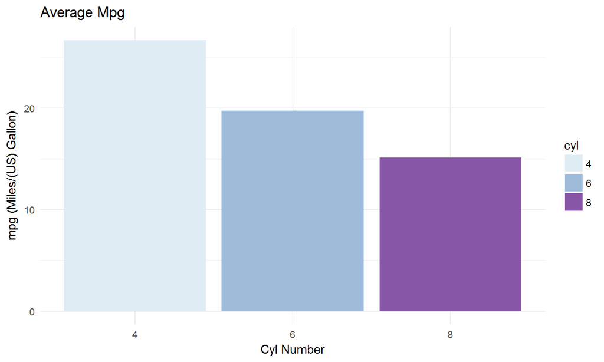

## Parameters and Features

Parameters available for plotting against cylinder number are:

```
## [1] "mpg"  "disp" "hp"   "drat" "wt"   "qsec" "carb"
```

*<sub>(Mpg, displacement, horsepower, rear axle ratio, weight, quarter-mile time and number of carburetors)</sub>*

The featured number of car cylinders are 4, 6 and 8.

- The plot changes in real-time based upon user-input in the response variables.
- The colour scheme of the plot is also adjustable, with four options.

## Uses of the App

This Shiny calculator gives quick insight into parameters such as average mpg, horsepower, and car weight, across the most common cylinder numbers.

- The app provides an opportunity to become (somewhat) educated on different car components and see how cylinder numbers can affect performance.
- The app can help predict, or estimate, how various car parameters (such as mpg, displacement, mile time, etc.) may vary based on cylinder number.
- The app's information may help future consumers in purchasing a vehicle. This information may also be invaluable as an easy research tool.

## Reasons to use the App

- Fairly plug-and-play
- Informative; lots of plot-able options
- Quick and easy-to-read information
- Does not require a gross amount of background knowledge; "child" friendly
- May help with future financial decisions/car choices

Given the large number of car choices, the looming concern of pollution in recent years, and current generations' increasingly divided time (as well as increasing sources of debt), this app may prove very useful for future generations.

[Source/full folder link](https://github.com/Namakuto/Creating-Data-Products)